# 第三章 R语言描述性分析

中国人民大学 统计学院  
周静

# 补充：正则表达式

- 正则表达式(regular expression)描述了一种字符串匹配的模式（pattern），可以用来检查一个串是否含有某种子串、将匹配的子串替换或者从某个串中取出符合某个条件的子串等。
- 例如：

  runoo+b，可以匹配 runoob、runooob、runoooooob 等，+ 号代表前面的字符必须至少出现一次（1次或多次）。

  runoo*b，可以匹配 runob、runoob、runoooooob 等，* 号代表字符可以不出现，也可以出现一次或者多次（0次、或1次、或多次）。

  colou?r 可以匹配 color 或者 colour，? 问号代表前面的字符最多只可以出现一次（0次、或1次）。
- 正则表达式的组件可以是单个的字符、字符集合、字符范围、字符间的选择或者所有这些组件的任意组合。
- 正则表达式是由普通字符（例如字符 a 到 z）以及特殊字符（称为“元字符”）组成的文字模式。
- R语言正则表达式总结：(https://www.jianshu.com/p/b3f70d96455f)
- 在线测试正则表达式的网页：(https://www.regexpal.com/)

# 特殊字符

- 所谓特殊字符，就是一些有特殊含义的字符，如上面说的 runoo*b 中的 *，简单的说就是表示任何字符串的意思。
- 如果要查找字符串中的 * 符号，则需要对 * 进行转义，R里转义使用的是双斜杠 \\
- 下表列出了正则表达式中的特殊字符：

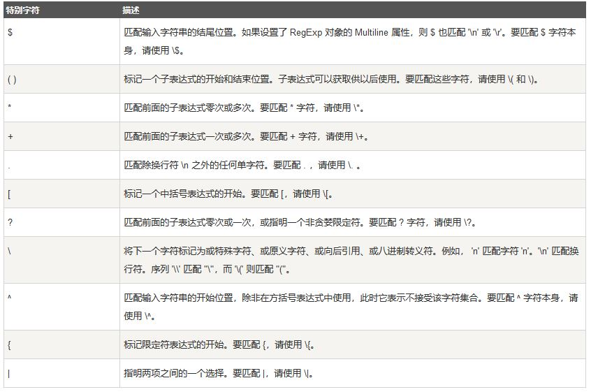

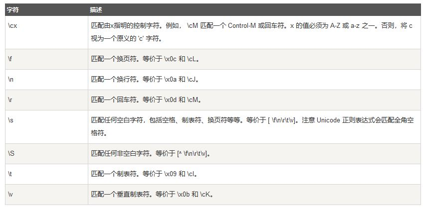

# 限定符

- 用来指定正则表达式的一个给定组件必须要出现多少次才能满足匹配。有 * 或 + 或 ? 或 {n} 或 {n,} 或 {n,m} 共6种。
- 正则表达式的限定符有：

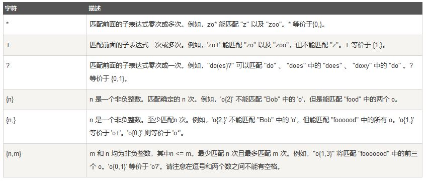

- 例如，匹配“第XX章”，其中“XX”的取值范围是1-130，那么可以写成：“第[1-9][0-9]*章”
- 如果章节数被限制在1-99章，你有哪些表示办法？
- 第[0-9]{1,2}章
- 第[1-9][0-9]?章
- 第[1-9][0-9]{0,1}章

# 定位符

- 定位符能够将正则表达式固定到行首或行尾。
- 定位符用来描述字符串或单词的边界，^ 和 $ 分别指字符串的开始与结束，\b 描述单词的前或后边界。

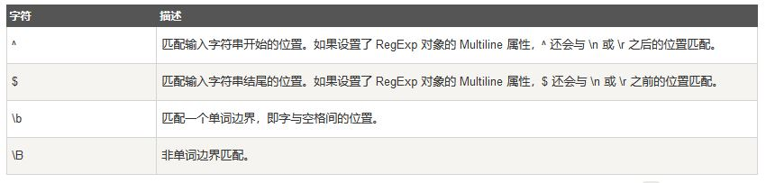

- 例如，上述例子章节的精确匹配：^第[1-9][0-9]{0,1}章$
- \b常用于匹配单词边界, 如想从字符串中“This is Regex”匹配单独的单词 “is” 正则就要写成 “\bis\b”

# 所有元字符总结

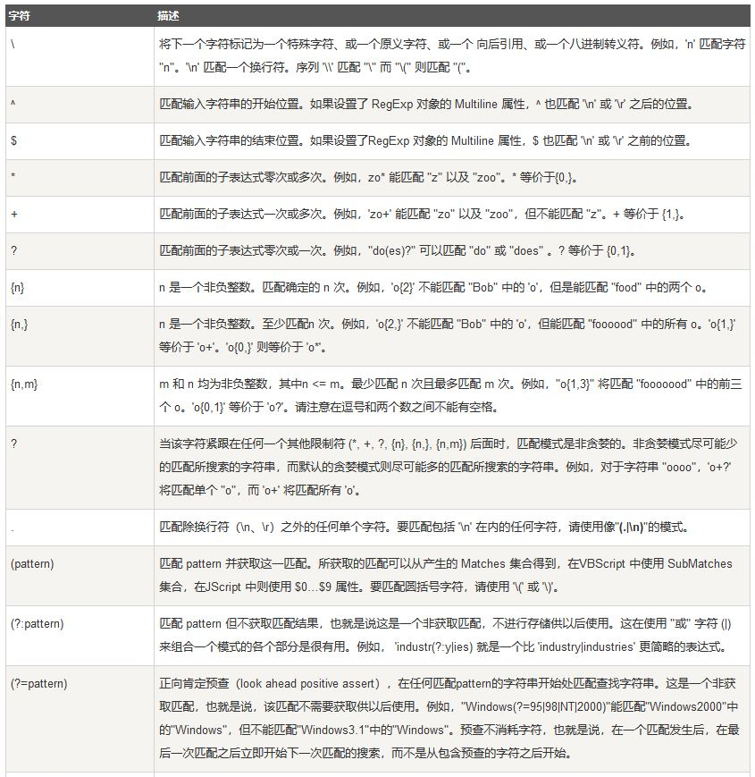

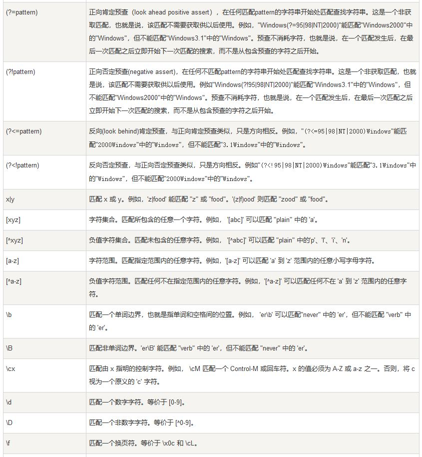

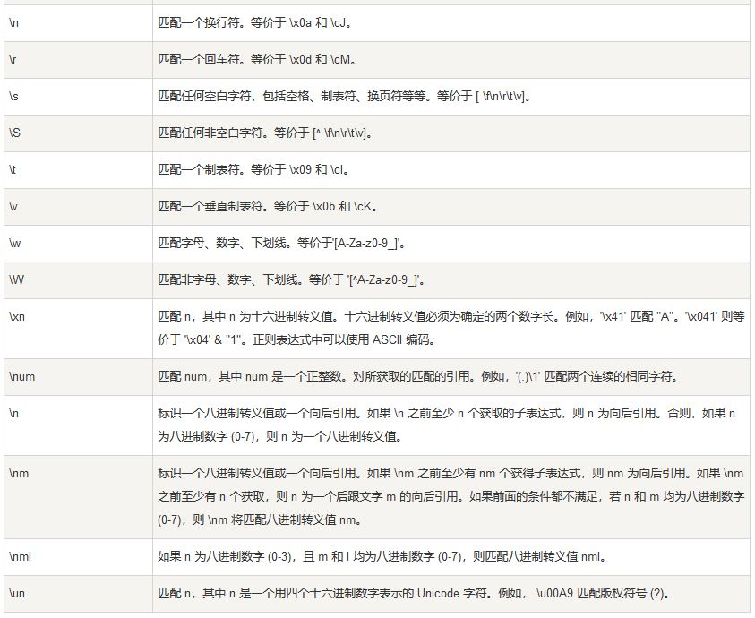

# 正则表达式练习

- 常用的函数有：
- stringr包
- grep, grepl, gsub, regexpr等

```r
library(stringr)
# ^：匹配字符串的开始，如^3表示匹配以”3”开头的字符。
test_vector<-c("123","456","321")
str_extract_all(test_vector,"^3")
## [[1]]
## character(0)
##
## [[2]]
## character(0)
##
## [[3]]
## [1] "3"
grep("^3",test_vector,value = TRUE)
```

```
## [1] "321"
```

```r
# $：匹配字符串的结束。如3$表示匹配3结尾的字符。
test_vector<-c("123","456$","321")
str_extract_all(test_vector,"3$")
## [[1]]
## [1] "3"
##
## [[2]]
## character(0)
##
## [[3]]
## character(0)
grep("3$",test_vector,value = FALSE)
```

```
## [1] 1
```

```r
# .：匹配除换行符以外的任意字符。
str_extract_all(string = c("regular.expressions\n","\n"), pattern ="\\.")
## [[1]]
## [1] "."
##
## [[2]]
## character(0)

# |：或者
test_vector2<-c("AlphaGo实在厉害！","alphago是啥","阿尔法狗是一条很凶猛的狗。")
str_extract_all(string = test_vector2, pattern ="AlphaGo|阿尔法狗")
## [[1]]
## [1] "AlphaGo"
##
## [[2]]
## character(0)
##
## [[3]]
## [1] "阿尔法狗"

# ?：前面的字符(组)是可有可无的，并且最多被匹配一次
str_extract_all(string = c("abc","ac","bc"),pattern = "ab?c")
## [[1]]
## [1] "abc"
##
## [[2]]
## [1] "ac"
##
## [[3]]
## character(0)
grep(pattern = "ab?c", c("abc","ac","bc"), value = TRUE)
```

```
## [1] "abc" "ac"
```

```r
# +：前面的字符(组)将被匹配一次或多次
str_extract_all(string = c("abababab","abc","ac"),pattern = "(ab)+")
## [[1]]
## [1] "abababab"
##
## [[2]]
## [1] "ab"
##
## [[3]]
## character(0)

# ( )：表示一个字符组，括号内的字符串将作为一个整体被匹配。
str_extract_all(string = c("ababc","ac","cde"),pattern = "(ab)?c")
## [[1]]
## [1] "abc"
##
## [[2]]
## [1] "c"
##
## [[3]]
## [1] "c"
grep(pattern = "(ab)?c",c("ababc","ac","cde"),value = TRUE)
```

```
## [1] "ababc" "ac"    "cde"
```

```r
str_extract_all(string = c("abc","ac","cde"),pattern = "ab?c")
## [[1]]
## [1] "abc"
##
## [[2]]
## [1] "ac"
##
## [[3]]
## character(0)
grep(pattern = "ab?c",c("abc","ac","cde"),value = TRUE)
```

```
## [1] "abc" "ac"
```

```r
str_extract_all(string = c("abababab","ababc","ababababc"),pattern = "(ab){2,3}")
## [[1]]
## [1] "ababab"
##
## [[2]]
## [1] "abab"
##
## [[3]]
## [1] "ababab"
grep(pattern = "(ab){2,3}",c("abababab","ababc","ababababc"),value = TRUE)
```

```
## [1] "abababab"  "ababc"     "ababababc"
```

```r
# 转义
# 如果我们想查找元字符本身，如”?”和”*“，我们需要提前告诉编译系统，取消这些字符的特殊含义。
# 这个时候，就需要用到转义字符\，即使用\?和\*.当然，如果我们要找的是\,则使用\\进行匹配。
# R里的转义字符是\\

strsplit(x="strsplit.aslo.uses.regular.expressions", split=".")
## [[1]]
##  [1] "" "" "" "" "" "" "" "" "" "" "" "" "" "" "" "" "" "" "" "" "" "" "" "" ""
## [26] "" "" "" "" "" "" "" "" "" "" "" "" ""
strsplit(x="strsplit.aslo.uses.regular.expressions", split="\\.")
## [[1]]
## [1] "strsplit"    "aslo"        "uses"        "regular"     "expressions"

str_extract_all(string = "my cridit card number: 34901358932236",pattern = "\\d")
## [[1]]
##  [1] "3" "4" "9" "0" "1" "3" "5" "8" "9" "3" "2" "2" "3" "6"

# 字符串的提取
text_weibo<- c("#围棋人机大战#【人工智能攻克围棋AlphaGo三比零完胜李世石】",
               "谷歌人工智能AlphaGo与韩国棋手李世石今日进行了第三场较量",
               "最终AlphaGo战胜李世石，连续取得三场胜利。接下来两场将沦为李世石的“荣誉之战。")

# str_match_all：返回的列表中的元素为矩阵

str_match_all(text_weibo,pattern = "#.+#")
## [[1]]
##      [,1]
## [1,] "#围棋人机大战#"
##
## [[2]]
##      [,1]
##
## [[3]]
##      [,1]

str_match_all(text_weibo, pattern = "[a-zA-Z]+")
## [[1]]
##      [,1]
## [1,] "AlphaGo"
##
## [[2]]
##      [,1]
## [1,] "AlphaGo"
##
## [[3]]
##      [,1]
## [1,] "AlphaGo"

# str_extract_all，返回的列表中的元素为向量
str_extract_all(text_weibo,pattern = "#.+#")
## [[1]]
## [1] "#围棋人机大战#"
##
## [[2]]
## character(0)
##
## [[3]]
## character(0)

str_extract_all(text_weibo, pattern = "[a-zA-Z]+")
## [[1]]
## [1] "AlphaGo"
##
## [[2]]
## [1] "AlphaGo"
##
## [[3]]
## [1] "AlphaGo"

# 读入课程信息数据，提取衍生指标课时和时间
b = read.csv("课程信息.csv", header = T, stringsAsFactors = F)           ##载入数据
names(b) = c("url","score","people","intro","detail")                    ##给变量命名

detail <- strsplit(b$detail, "|", fixed = T)  # 使用'|'进行分割
hour <- sapply(detail, function(x){length(grep("课时[0-9]", x, value = TRUE))})  # 匹配课时信息，统计每一个课程有几个课时
summary(hour)
```

```
##    Min. 1st Qu.  Median    Mean 3rd Qu.    Max.
##   0.000   3.000   5.000   8.354  10.000 232.000
```

```r
each.time <- sapply(detail, function(x){grep("[0-9]:[0-9]", x, value = TRUE)})

# 思考：如果想进一步计算每门课所有课时的时间该怎么办？
```

# 描述分析及可视化

[figure not shown]

- 对数据的描述分析（如何画基本统计图形）
- 描述分析在数据分析过程中的重要地位
  - 建模前：观察数据、发现问题、识别异常与规律
  - 建模后：总结规律、表现结论、传递信息
- 了解和学习基本的作图方法
- 从 base 包入手，介绍统计基本图表的实现

# 描述分析及可视化：统计的基本图表

- 最常用的图表类型：柱箱点、折直饼
  - 柱状图
  - 箱线图
  - 散点图
  - 折线图
  - 直方图
  - 饼图
- 两个问题：针对不同变量类型、 不同变量个数展现时使用不同工具
  - 描述一个变量还是两个变量（多个变量展示通常是基础图的组合）
  - 描述的变量是什么类型（定性变量还是定量变量？）
- 图形选用

# 图使用的场景及其 R 语言实现

- 案例数据：小说数据

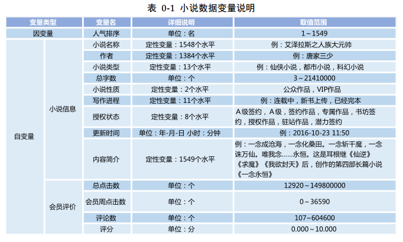

- 读入、查看数据

```r
#读入数据
novel=read.csv("novel.csv",stringsAsFactor = F, fileEncoding = "GBK")
#数据查看与异常处理
summary(novel)
```

```
##     人气排序      小说名称             作者             小说类型
##  Min.   :   1   Length:1549        Length:1549        Length:1549
##  1st Qu.: 388   Class :character   Class :character   Class :character
##  Median : 775   Mode  :character   Mode  :character   Mode  :character
##  Mean   : 775
##  3rd Qu.:1162
##  Max.   :1549
##
##     总点击数          会员周点击数         总字数             评论数
##  Min.   :    12915   Min.   :    0.0   Min.   :    3341   Min.   :   107
##  1st Qu.:   210840   1st Qu.:   27.0   1st Qu.:  882845   1st Qu.:  1475
##  Median :   492110   Median :   87.0   Median : 1885722   Median :  3373
##  Mean   :  2534724   Mean   :  317.4   Mean   : 2434579   Mean   : 16884
##  3rd Qu.:  1218732   3rd Qu.:  223.5   3rd Qu.: 3430881   3rd Qu.:  9546
##  Max.   :149842883   Max.   :36587.0   Max.   :21410094   Max.   :604560
##  NA's   :2           NA's   :2         NA's   :2
##       评分          小说性质           写作进程           授权状态
##  Min.   : 0.000   Length:1549        Length:1549        Length:1549
##  1st Qu.: 9.300   Class :character   Class :character   Class :character
##  Median : 9.700   Mode  :character   Mode  :character   Mode  :character
##  Mean   : 8.926
##  3rd Qu.: 9.900
##  Max.   :10.000
##
##    更新时间           内容简介
##  Length:1549        Length:1549
##  Class :character   Class :character
##  Mode  :character   Mode  :character
##
##
##
##
```

```r
novel=na.omit(novel)
dim(novel)
```

```
## [1] 1547   14
```

# 基础描述分析： 单变量作图（定性变量）

- 定性变量（柱状图和饼图）
  - 性别、 国籍这类描述一个事物质的特性的变量
  - 取值离散，比如男、 女，中国、 英国等
- 柱状图
  - 适合展示一个定性变量的频数分布
  - 也可用来观察不同类别样本的分布
  - 函数：barplot()
- 柱状图：查看数据中排名前五的小说类型的频数分布

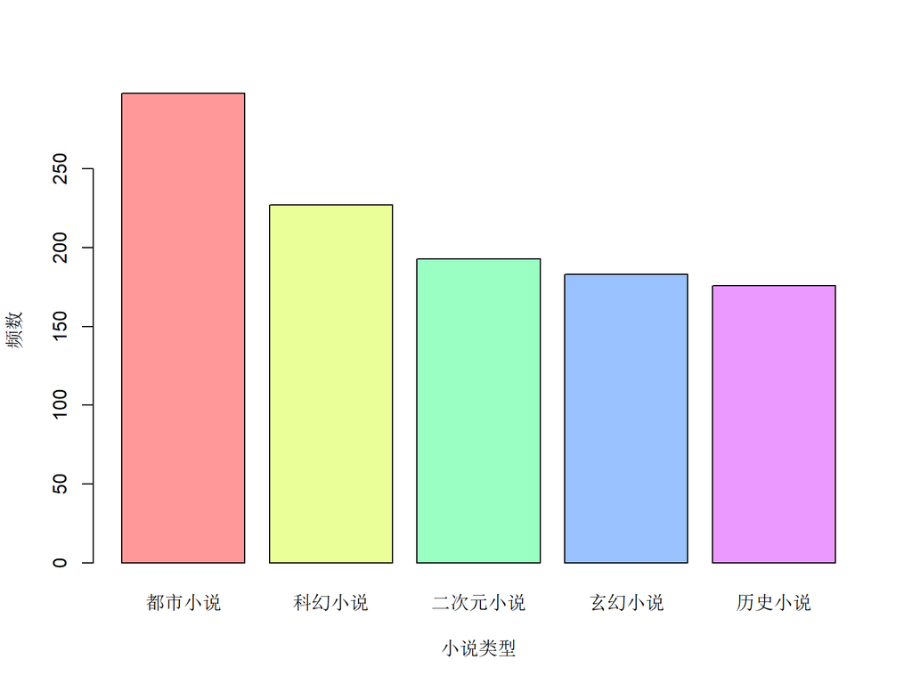

```r
a=table(novel$小说类型)
a=a[order(a,decreasing = T)]
barplot(a[1:5],names.arg = names(a)[1:5],col=rainbow(5,alpha=0.4),xlab = "小说类型",ylab="频数")
```

- 饼图
  - 也可展现数量对比
  - 可展示比例
  - 函数：pie()
- 饼图：熊粉成员分布，展示各自比例

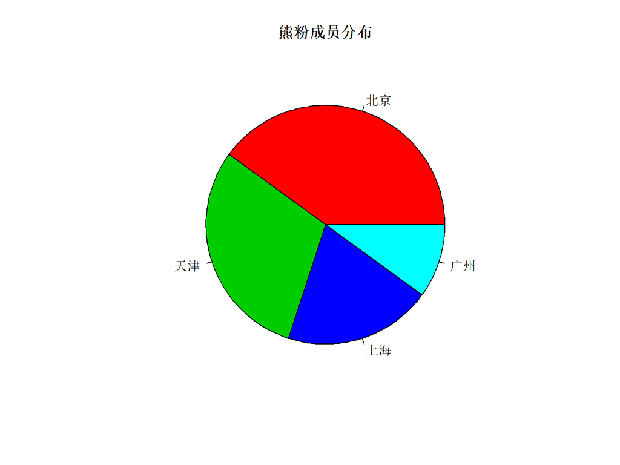

```r
pie(c(4000,3000,2000,1000),labels = c("北京","天津","上海","广州"),main="熊粉成员分布",col=2:5)
```

- 更美观的饼图：小说数据

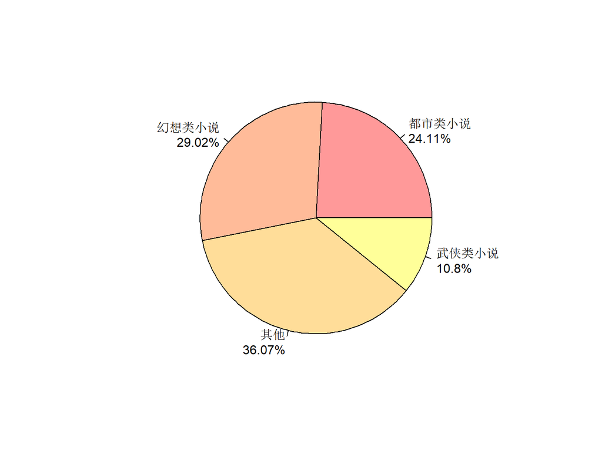

```r
#将小说类型进行简要合并
novel$'小说类别'<-"其他"
novel$'小说类别'[novel$小说类型=="都市小说"|novel$小说类型=="职场小说"] <- "都市类小说"
novel$'小说类别'[novel$小说类型=="科幻小说"|novel$小说类型=="玄幻小说"|novel$小说类型=="奇幻小说"] <- "幻想类小说"
novel$'小说类别'[novel$小说类型=="武侠小说"|novel$小说类型=="仙侠小说"] <- "武侠类小说"
#求出每一类所占百分比
ratio=table(novel$'小说类别')/sum(table(novel$'小说类别'))*100
#定义标签
label1=names(ratio)
label2=paste0(round(ratio,2),"%")
#画饼图
pie(ratio,col=heat.colors(5,alpha = 0.4),labels = paste(label1,label2,sep="\n"),font=1)
```

# 基础描述分析： 单变量作图（定量变量）

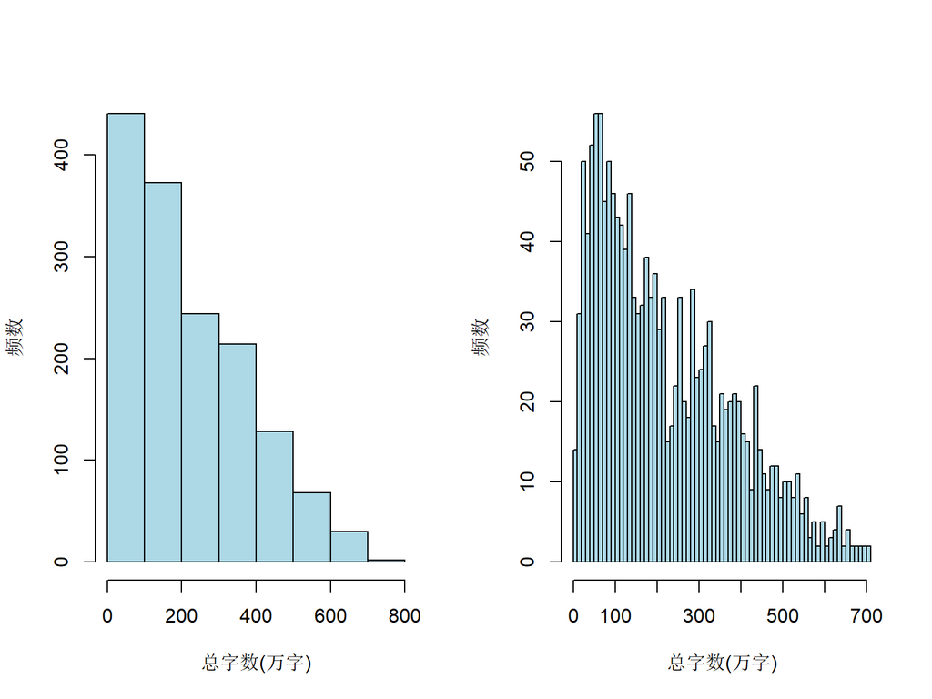

```r
novel$总字数=novel$总字数/10000
par(mfrow=c(1,2))
chara=sort(novel$总字数)[1:1500] #去掉异常值
hist(chara,breaks=10,xlab="总字数(万字)",ylab="频数",main="",col="lightblue")
hist(chara,breaks=100,xlab="总字数(万字)",ylab="频数",main="",col="lightblue")
```

- 折线图
  - 时间序列数据
  - 指标随时间变化的趋势
  - plot(x)
- 折线图

```r
par(mfrow=c(1,1))
#画时间序列图
data(AirPassengers)
head(AirPassengers)
```

```
## [1] 112 118 132 129 121 135
```

```r
class(AirPassengers)
```

```
## [1] "ts"
```

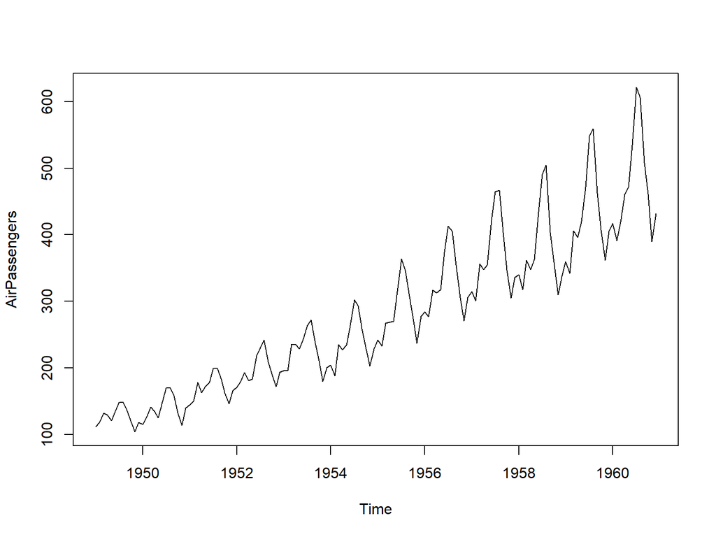

```r
plot(AirPassengers)
```

- 人民的名义百度搜索指数图

```r
library(zoo)
#将搜索指数index变成时间序列格式
index=c(127910,395976,740802,966845,1223419,1465722,1931489,2514324,3024847,3174056,3208696,3644736,4198117,3868350,3576440,
        3524784,3621275,3695967,3728965,3845193,3525579,3452680,3535350,3655541,3884779,3780629)/10000
date<-seq(as.Date("2017-3-28"), length=26, by="day")
people_index <- zoo(index, date)
class(people_index)
```

```
## [1] "zoo"
```

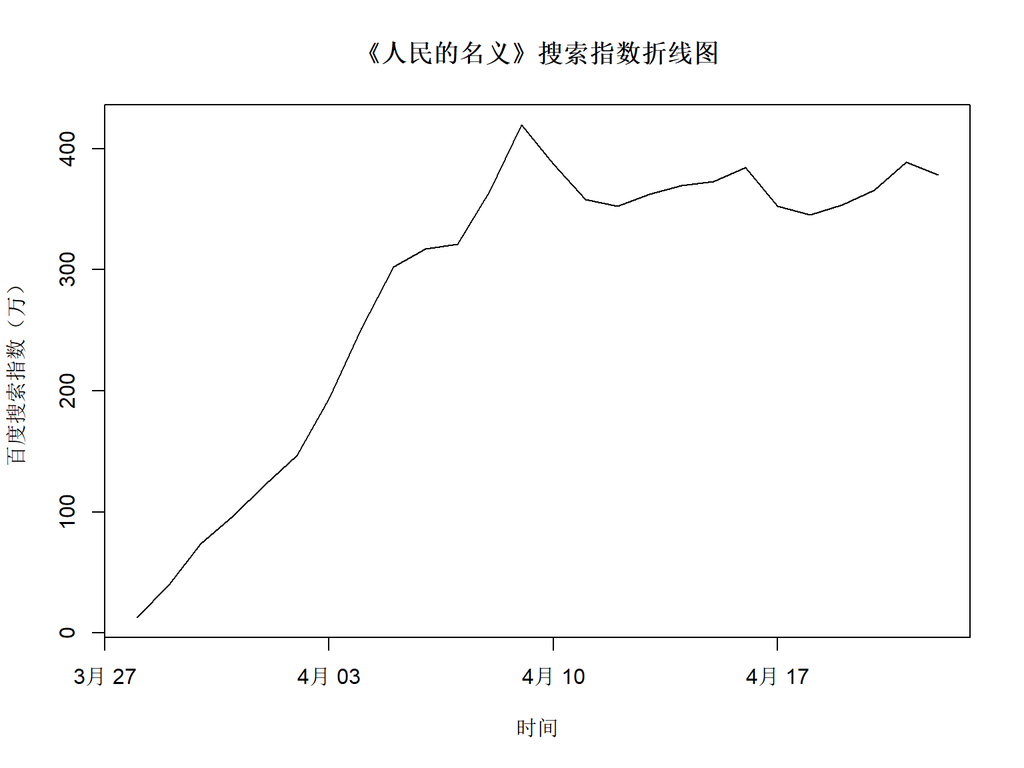

```r
plot(people_index,xlab = "时间",ylab="百度搜索指数（万）",main = "《人民的名义》搜索指数折线图")
```

[figure not shown]

```r
#更改坐标轴显示内容
plot(people_index,xaxt="n",xlab = "时间",ylab="百度搜索指数（万）",main = "《人民的名义》搜索指数折线图")
times <- date #or directly times=x.Date
ticks <- seq(times[1], times[length(times)], by = "weeks") ## month, weeks, year etc.
label_name=c("3月28日","4月4日","4月11日","4月18日")
axis(1, at = ticks, labels = label_name)
```

# 基础描述分析： 两个变量（定性与定量变量）

- 如何切分画板
  - 将两个变量各放一张图，摆在一起对着看
  - par(mfrow=c(a,b)):将画图的屏幕切分成 a 行 b 列个小格子
- 定性与定量变量
  - 在某个分类变量的标准下，比较另一个定量变量
  - 比如比较不同教育水平的收入差异这些就是的表现
- 分组箱线图：公众作品每部作品点击数与 VIP 作品比较
  - boxplot(y~x)

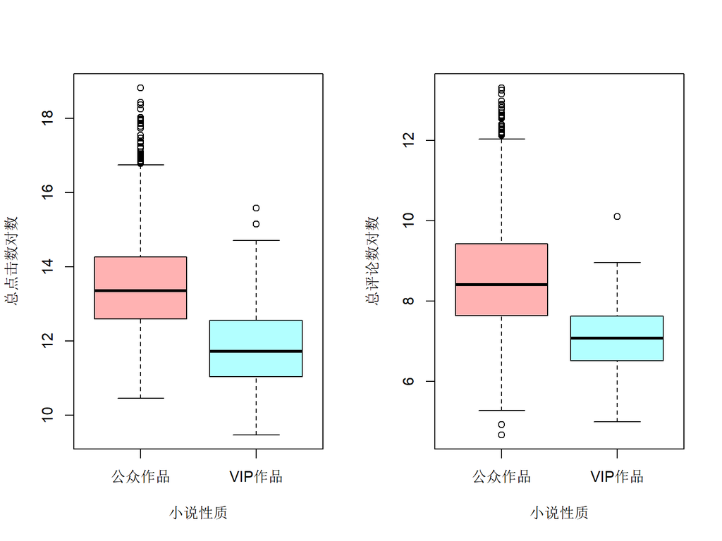

```r
#将画板分成1行2列
par(mfrow=c(1,2))
#不同性质的小说总点击数和评论数有差别吗
boxplot(log(总点击数)~小说性质,data=novel,col = rainbow(2,alpha = 0.3),names=c("公众作品","VIP作品"),ylab="总点击数对数")
boxplot(log(评论数)~小说性质,data=novel,col = rainbow(2,alpha = 0.3),names=c("公众作品","VIP作品"),ylab="总评论数对数")
```

# 基础描述分析： 两个变量（定量）

- 散点图
  - 观察两变量的相关方向及相关程度
  - 解释相关性：
  - plot(x,y)

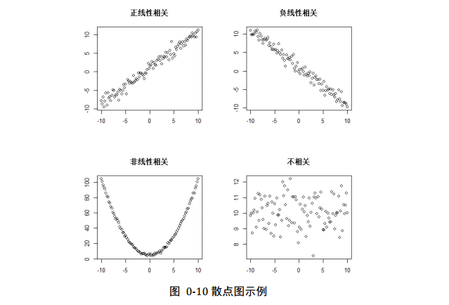

- 散点图：小说的总点击数和评论数有何关联

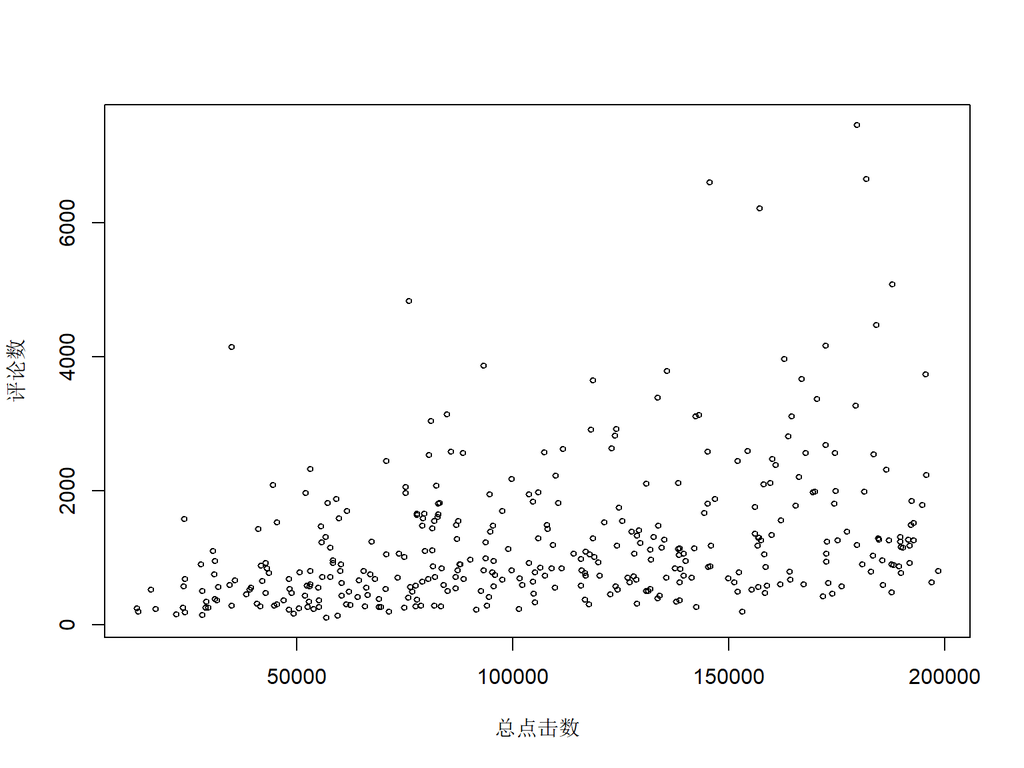

```r
#将画板恢复
par(mfrow=c(1,1))

#去除较大的异常值后画图
test=novel[novel$评论数< 8000 & novel$总点击数<200000,]
x=test$总点击数
y=test$评论数
plot(x,y,pch=1,cex=0.6,xlab="总点击数",ylab="评论数")
```

- 离散化：分组做分组箱线图

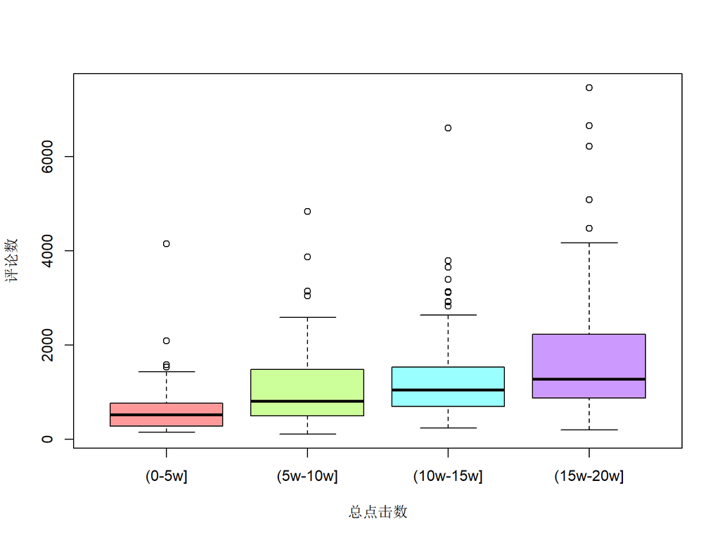

```r
aa=cut(x,breaks =c(0,50000,100000,150000,200000),labels = c("(0-5w]","(5w-10w]","(10w-15w]","(15w-20w]"))
boxplot(y~aa,col=rainbow(4,alpha = 0.4),xlab="总点击数",ylab="评论数")
```

- 散点图矩阵

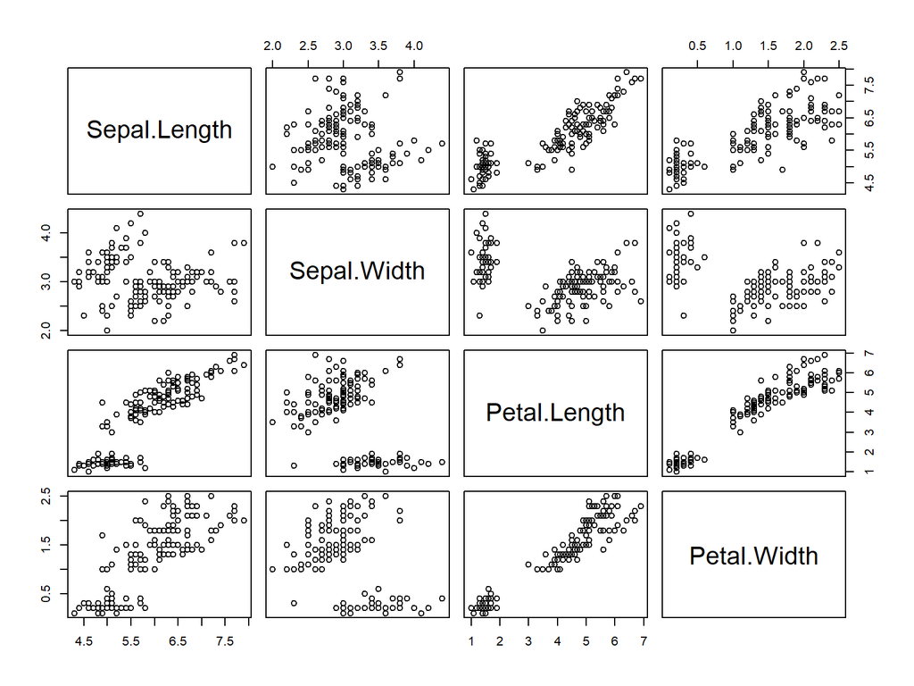

```r
plot(iris[,1:4])
```

# 基础描述分析： 两个变量（定性）

- 柱状图
  - 堆积柱状图
  - 并列（分组） 柱状图
- 两种柱状图的效果

```r
library(plyr)
library(reshape2)
a=ddply(novel,.(小说类别,小说性质),nrow)
d=dcast(a,小说性质~ 小说类别)[,-1]
## Using V1 as value column: use value.var to override.
rownames(d)=c("VIP作品", "大众作品")
d=as.matrix(d)
d
```

```
##          都市类小说 幻想类小说 其他 武侠类小说
## VIP作品         339        404  370        149
## 大众作品         34         45  188         18
```

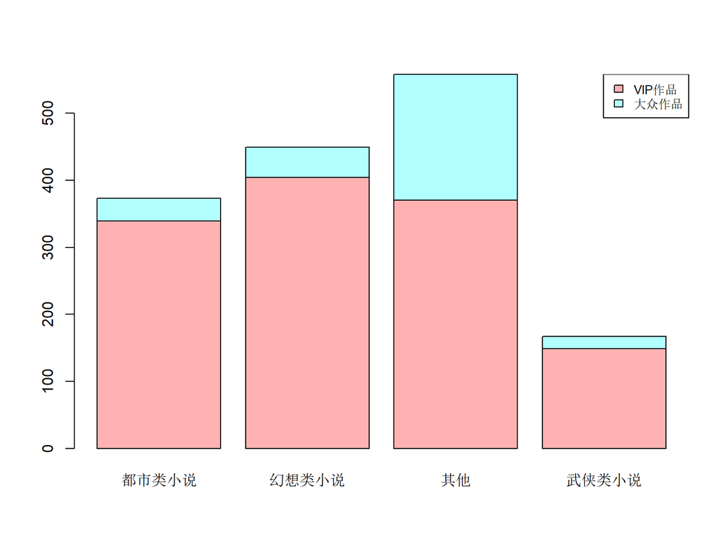

```r
#beside=F,按列堆积
barplot(d,beside = F,col = rainbow(2,alpha = 0.3))
legend("topright",legend= c("VIP作品", "大众作品"),
       fill=rainbow(2,alpha = 0.3),
       cex = 0.8)
```

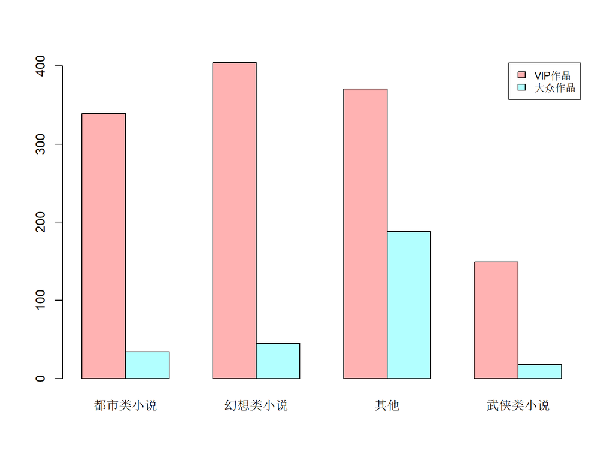

```r
#beside=T,按行堆积
barplot(d,beside = T,col = rainbow(2,alpha = 0.3))
legend("topright",legend= c("VIP作品", "大众作品"),
       fill=rainbow(2,alpha = 0.3),
       cex = 0.8)
```